# ONLINE SUPPLEMENT: Quantifying macro-evolutionary patterns of trait mean and variance with phylogenetic location-scale models

- Show All Code
- Hide All Code
- View Source

Author

Nakagawa, Shinichi, Ayumi Mizuno, Coralie Williams, Malgorzata Lagisz, Yefeng Yang, and Szymon M Drobniak

Published

September 9, 2025

# 1 Introduction

This online material is a supplement to our paper “Quantifying macro-evolutionary patterns of trait mean and variance with phylogenetic location-scale models”. You will see how to fit phylogenetic location-scale models (PLSMs) in a Bayesian framework using `brms` package in `R`. All the code and related data are available in this repository [here](https://github.com/itchyshin/phylo_location_scale).

# 2 Contents

In this online material, we will first introduce how to fit phylogenetic *location-only* models (nomral phylgoenetic mixed-effects model) using `brms`.

Then, we will illustrate how to fit three models described in our paper, subtitled as:

- Different Trait Variance in Two Groups (Model 3)
- Co-evolution of Mean and Variance (Model 4)
- Co-evolution of Two Traits (Model 5)

All results presented in this online material are for illustrative purposes only (more careful thoughts are required to draw biological conclusions).

Additionally, we will show how to obtain phylogenetic heritability and macro-evolvability from the fitted `brms` object.

Also, importantly, there is a paper, which focuses on location-scale meta-analytic and meta-regression. You can find the sister paper’s tutorial [here](https://itchyshin.github.io/location-scale_meta-analysis/#multilevel-meta-analysis-and-location-scale-meta-regression); also, the preprint of this sister paper is available on [DOI](https://doi.org/10.1111/gcb.70204):

> Nakagawa, S., Mizuno, A., Morrison, K., Ricolfi, L., Williams, C., Drobniak, S. M., … & Yang, Y. (2025). Location‐Scale Meta‐Analysis and Meta‐Regression as a Tool to Capture Large‐Scale Changes in Biological and Methodological Heterogeneity: A Spotlight on Heteroscedasticity. Global Change Biology, 31(5), e70204.

This tutorial has several tips to run location-scale models using `brms`.

Furthermore, there are two papers, which teaches Bayesian generalised linear modelling.

The first one’s tutorial [here](https://github.com/Benjamin-Halliwell/MR-PMM); also, the preprint is available on [DOI](https://doi.org/10.1111/brv.70001):

> Halliwell, B., Holland, B. R., & Yates, L. A. (2025). Multi‐response phylogenetic mixed models: concepts and application. Biological Reviews, 100(3), 1294-1316.

The second one’s tutorial [here](https://ayumi-495.github.io/multinomial-GLMM-tutorial/); also, the preprint is available on [EcoEvoRxiv](https://ecoevorxiv.org/repository/view/8458/):

> Mizuno, A., Drobniak, S.M., Williams, C., Lagisz, M. and Nakagawa, S., 2025. Promoting the use of phylogenetic multinomial generalised mixed-effects model to understand the evolution of discrete traits. EcoEvoRxiv. 2025.

Also, these tutorials teach you how to diagnose Bayesian models and how to interpret the results.

# 3 Prerequisites

## 3.1 Loading pacakges

Our tutorial uses `R` statistical software and existing `R` packages, which you will first need to download and install.

If the packages are archived in CRAN, use `install.packages()` to install them. For example, to install the `brms` , you can execute `install.packages("brms")` in the console (bottom left pane of `R Studio`).

Version information of each package is listed at the end of this tutorial.

```r
# attempt to load or install necessary packages
if(!require(pacman)) install.packages("pacman")
pacman::p_load(tidyverse,
               ggplot2,
               brms,
               bayesplot,
               tidybayes,
               here,
               ape,
               patchwork,
               pander,
               stringr,
               tibble,
               dplyr
)

html_out <- knitr::is_html_output()
```

## 3.2 Custom functions

We also provide some additional helper functions to help visualize the results (mainly extracted from the `brms` object). If you want to use these custom functions in your own data, you’ll need to change the variable names according to your own data (check out the `R` code and you’ll see what we mean).

```r
# Function to get variable names dynamically
get_variables_dynamic <- function(model, pattern) {
  variables <- get_variables(model)
  variables[grep(pattern, variables)]
}

rename_vars <- function(variable) {
  # b
  variable <- gsub("b_Intercept", "l_int", variable)
  variable <- gsub("b_sigma_Intercept", "s_int", variable)
  variable <- gsub("b_cmass", "l_cmass", variable)
  variable <- gsub("b_sigma_cmass", "s_cmass", variable)
  variable <- gsub("b_forest", "l_contrast", variable)
  variable <- gsub("b_sigma_forest", "s_contrast", variable)
  # mod3
  variable <- gsub("b_cbeakwidth_Intercept", "l_width_int", variable)
  variable <- gsub("b_sigma_cbeakwidth_Intercept", "s_width_int", variable)
  variable <- gsub("b_cbeakdepth_Intercept", "l_depth_int", variable)
  variable <- gsub("b_sigma_cbeakdepth_Intercept", "s_depth_int", variable)
  variable <- gsub("b_cbeakwidth_cmass", "l_width_cmass", variable)
  variable <- gsub("b_sigma_cbeakwidth_cmass", "s_width_cmass", variable)
  variable <- gsub("b_cbeakdepth_cmass", "l_depth_cmass", variable)
  variable <- gsub("b_sigma_cbeakdepth_cmass", "s_depth_cmass", variable)

  # sd
  variable <- gsub("sd_Phylo__Intercept", "l_sd", variable)
  variable <- gsub("sd_Phylo__sigma_Intercept", "s_sd", variable)
  # mod3
  variable <- gsub("sd_Phylo__cbeakwidth_Intercept", "l_width_sd", variable)
  variable <- gsub("sd_Phylo__sigma_cbeakwidth_Intercept", "s_width_sd", variable)
  variable <- gsub("sd_Phylo__cbeakdepth_Intercept", "l_depth_sd", variable)
  variable <- gsub("sd_Phylo__sigma_cbeakdepth_Intercept", "s_depth_sd", variable)

  # corr
  variable <- gsub("cor_Phylo__Intercept__sigma_Intercept", "ls_cor", variable)
  # mod3
  variable <- gsub("cor_Phylo__cbeakwidth_Intercept__sigma_cbeakwidth_Intercept", "ls_width-width_cor", variable)
  variable <- gsub("cor_Phylo__cbeakwidth_Intercept__cbeakdepth_Intercept", "ll_width-depth_cor", variable)
  variable <- gsub("cor_Phylo__sigma_cbeakwidth_Intercept__cbeakdepth_Intercept", "sl_width-depth_cor", variable)
  variable <- gsub("cor_Phylo__cbeakwidth_Intercept__sigma_cbeakdepth_Intercept", "ls_width-depth_cor", variable)
  variable <- gsub("cor_Phylo__sigma_cbeakwidth_Intercept__sigma_cbeakdepth_Intercept", "ss_width-depth_cor", variable)
  variable <- gsub("cor_Phylo__cbeakdepth_Intercept__sigma_cbeakdepth_Intercept", "ls_depth-depth_cor", variable)

  return(variable)
}


# Function to visualize fixed effects
visualize_fixed_effects <- function(model) {
  fixed_effect_vars <- get_variables_dynamic(model, "^b_")
  if (length(fixed_effect_vars) == 0) {
    message("No fixed effects found")
    return(NULL)
  }

  tryCatch({
    fixed_effects_samples <- model %>%
      spread_draws(!!!syms(fixed_effect_vars)) %>%
      pivot_longer(cols = all_of(fixed_effect_vars), names_to = ".variable", values_to = ".value") %>%
      mutate(.variable = rename_vars(.variable))

    ggplot(fixed_effects_samples, aes(x = .value, y = .variable)) +
      stat_halfeye(
        normalize = "xy",
        point_interval = "mean_qi",
        fill = "lightcyan3",
        color = "lightcyan4"
      ) +
      geom_vline(xintercept = 0, linetype = "dashed", color = "#005") +
      labs(y = "Fixed effects", x = "Posterior values") +
      theme_classic()
  }, error = function(e) {
    message("Error in visualize_fixed_effects: ", e$message)
    return(NULL)
  })
}

# Function to visualize random effects
visualize_random_effects <- function(model) {
  random_effect_vars <- get_variables_dynamic(model, "^sd_")
  random_effect_vars <- random_effect_vars[random_effect_vars != "sd_es_ID__Intercept"]
  if (length(random_effect_vars) == 0) {
    message("No random effects found")
    return(NULL)
  }

  tryCatch({
    random_effects_samples <- model %>%
      spread_draws(!!!syms(random_effect_vars)) %>%
      pivot_longer(cols = all_of(random_effect_vars), names_to = ".variable", values_to = ".value") %>%
      mutate(.variable = rename_vars(.variable)) #%>%
      #mutate(.value = .value)  # leave SD as it is

    ggplot(random_effects_samples, aes(x = .value, y = .variable)) +
      stat_halfeye(
        normalize = "xy",
        point_interval = "mean_qi",
        fill = "olivedrab3",
        color = "olivedrab4"
      ) +
      geom_vline(xintercept = 0, linetype = "dashed", color = "#005") +
      labs(y = "Random effects (SD)", x = "Posterior values") +
      theme_classic()
  }, error = function(e) {
    message("Error in visualize_random_effects: ", e$message)
    return(NULL)
  })
}

# Function to visualize correlations
visualize_correlations <- function(model) {
  correlation_vars <- get_variables_dynamic(model, "^cor_")
  if (length(correlation_vars) == 0) {
    message("No correlations found")
    return(NULL)
  }

  tryCatch({
    correlation_samples <- model %>%
      spread_draws(!!!syms(correlation_vars)) %>%
      pivot_longer(cols = all_of(correlation_vars), names_to = ".variable", values_to = ".value") %>%
      mutate(.variable = rename_vars(.variable))

    ggplot(correlation_samples, aes(x = .value, y = .variable)) +
      stat_halfeye(
        normalize = "xy",
        fill = "#FF6347",
        color = "#8B3626"
      ) +
      geom_vline(xintercept = 0, linetype = "dashed", color = "#005") +
      labs(y = "Correlations", x = "Posterior values") +
      theme_classic()
  }, error = function(e) {
    message("Error in visualize_correlations: ", e$message)
    return(NULL)
  })
}
```

# 4 Data loading and preparation

We use the data from **Avonet**:

> J. A. Tobias, C. Sheard, A. L. Pigot, A. J. Devenish, J. Yang, F. Sayol, M. H. Neate-Clegg, N. Alioravainen, T. L. Weeks, R. A. Barber, et al. Avonet: morphological, ecological and geographical data for all birds. Ecology Letters, 25(3):581–597, 2022

As described in the paper, we only use parrot species (*N* = 354) and we use phylogenetic trees form Jetz et al. (2012):

> W. Jetz, G. H. Thomas, J. B. Joy, K. Hartmann, and A. O. Mooers. The global diversity of birds in space and time. Nature, 491(7424):444–448, 2012

```r
# load data
dat <- read.csv(here("data", "Psittaciformes", "Psittaciformes_354spp.csv"))

#str(dat)

# reading nexus file (use ape package)
tree_all <- read.nexus(here("data", "Psittaciformes", "Psittaciformes_354spp_100.nex"))
tree <- tree_all[[1]]

# Turning phylogenetic tree into phylognetic correlation matrix
A <- vcv.phylo(tree, corr = TRUE)

# center data of interest
dat$cbeak_length <- scale(log(dat$Beak.Length_Culmen), center = TRUE, scale = FALSE)
dat$cbeak_width <- scale(log(dat$Beak.Width), center = TRUE, scale = FALSE)
dat$cbeak_depth <- scale(log(dat$Beak.Depth), center = TRUE, scale = FALSE)
dat$cmass <- scale(log(dat$Mass), center = TRUE, scale = FALSE)
dat$crange_size <- scale(log(dat$Range.Size), center = TRUE, scale = FALSE)

# phynotipic correlation among three beak traits
# cor(dat$cbeak_length, dat$cbeak_width)
# cor(dat$cbeak_length, dat$cbeak_depth)
# cor(dat$cbeak_width, dat$cbeak_depth)

# create a variable which says whether they live in Forest or not
dat$forest <- ifelse(dat$Habitat == "Forest", 1, 0)
```

We use the following variables in our models:

- `cbeak_length`: log-transformed and centred beak length (`Beak.Length_Culmen`)
- `cbeak_width`: log-transformed and centred beak width (`Beak.Width`)
- `cbeak_depth`: log-transformed and centred beak depth (`Beak.Depth`)
- `cmass`: log-transformed and centred body mass (`Mass`)
- `crange_size`: log-transformed and centred range size (`Range.Size`)
- `forest`: a binary variable indicating whether the species lives in the forest or other habits (created based on `Habitat`)

# 5 A baseline: fitting a *location-only* phylogenetic model

## 5.1 Fitting the model

```r
# creating the formula
form0 <- bf(cbeak_length ~ 1 + cmass + forest +
              (1 | gr(Phylo, cov = A)) # phylogenetic random effect
)

# setting priors
prior0 <- default_prior(form0,
                        data = dat,
                        data2 = list(A = A),
                        family = gaussian()
)

# running the model
mod0 <- brm(form0,
            data = dat,
            data2 = list(A = A),
            chains = 2,
            cores = 2,
            iter = 8000,
            warmup = 5000,
            prior = prior0,
            control = list(adapt_delta = 0.99, max_treedepth = 15)
)

# time taken to run the model
#  179.714 seconds (Total)

saveRDS(mod0, here("Rdata", "mod0.rds"))
```

Check the results:

```r
mod0 <- readRDS(here("Rdata", "mod0.rds"))

summary(mod0)
##  Family: gaussian
##   Links: mu = identity; sigma = identity
## Formula: cbeak_length ~ 1 + cmass + forest + (1 | gr(Phylo, cov = A))
##    Data: dat (Number of observations: 353)
##   Draws: 2 chains, each with iter = 8000; warmup = 5000; thin = 1;
##          total post-warmup draws = 6000
##
## Multilevel Hyperparameters:
## ~Phylo (Number of levels: 353)
##               Estimate Est.Error l-95% CI u-95% CI Rhat Bulk_ESS Tail_ESS
## sd(Intercept)     0.26      0.03     0.20     0.32 1.00      605     1151
##
## Regression Coefficients:
##           Estimate Est.Error l-95% CI u-95% CI Rhat Bulk_ESS Tail_ESS
## Intercept     0.02      0.14    -0.25     0.30 1.00     2006     2917
## cmass         0.34      0.02     0.31     0.37 1.00     1634     3672
## forest        0.03      0.02    -0.01     0.06 1.00     4329     4685
##
## Further Distributional Parameters:
##       Estimate Est.Error l-95% CI u-95% CI Rhat Bulk_ESS Tail_ESS
## sigma     0.09      0.01     0.08     0.11 1.00      633     1294
##
## Draws were sampled using sampling(NUTS). For each parameter, Bulk_ESS
## and Tail_ESS are effective sample size measures, and Rhat is the potential
## scale reduction factor on split chains (at convergence, Rhat = 1).
```

## 5.2 Visualizing results

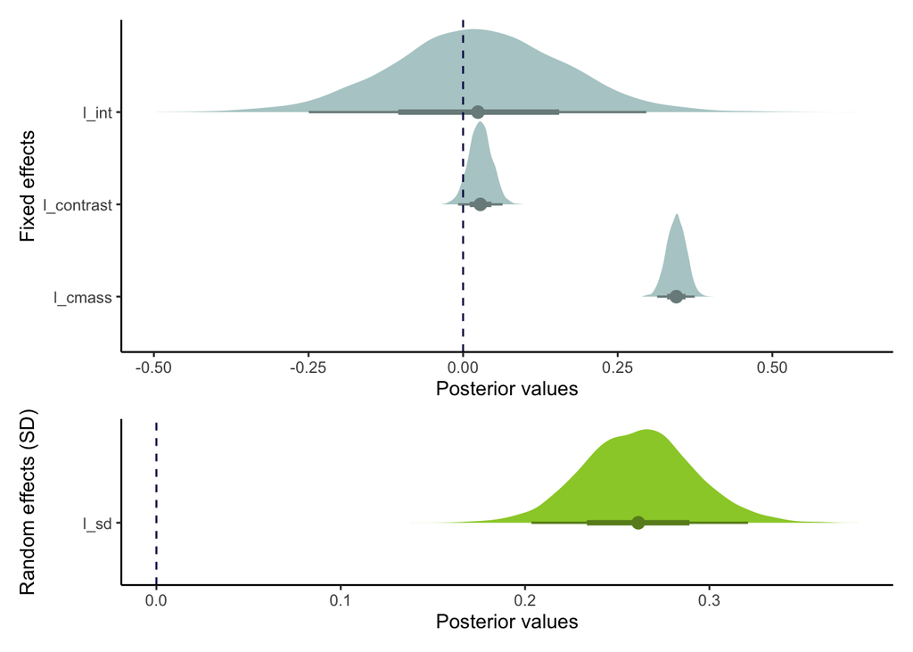

```r
# Fixed and random effects
plots_mod0 <- list(
  visualize_fixed_effects(mod0),
  visualize_random_effects(mod0)
)

plots_mod0[[1]] / plots_mod0[[2]] + plot_layout(heights = c(2, 1))
```

**Posterior distributions of different types of parameters**; the vertical dashed line indicates zero, aiding the interpretation of effect direction with thick lines showing 66% credible intervals and thin whiskers 95% credible intervals (not spanning zero being interpreted as ‘statistical significant’).

## 5.3 Result summary

- Larger-bodied species consistently show higher average beak length than smaller-bodied species (as expected, we were controlling for body size).
- Species living in the forest have larger beak length than those living in other habitats although non-significant.

# 6 Different trait variance in two groups (Model 3)

In this first phylogenetic location-scale model (PLSM), we will fit a location-scale model to investigate whether the mean and variance of beak length (`cbeak_length`) differs between species living in the forest and those living in other habitats.

## 6.1 Fitting the model

The `brms` syntax for Model 3 is as follows:

```r
# creating the formula
form1 <- bf(cbeak_length ~ 1 + cmass + forest +
              (1 | gr(Phylo, cov = A)), # how to model phylogenetic correlation
         sigma ~ 1 + cmass + forest
)

# setting priors
prior1 <- default_prior(form1,
                        data = dat,
                        data2 = list(A = A),
                        family = gaussian()
)

# running the model
mod1 <- brm(form1,
            data = dat,
            data2 = list(A = A),
            chains = 2,
            cores = 2,
            iter = 80000,
            warmup = 20000,
            prior = prior1,
            control = list(adapt_delta = 0.99, max_treedepth = 15)
)

# time taken to run the model
#  8673 seconds (Total)

# saving
saveRDS(mod1, here("Rdata", "mod1.rds"))
```

Check the results:

```r
# loading and checking
mod1 <- readRDS(here("Rdata", "mod1.rds"))

summary(mod1)
## Warning: There were 329 divergent transitions after warmup. Increasing
## adapt_delta above 0.99 may help. See
## http://mc-stan.org/misc/warnings.html#divergent-transitions-after-warmup
##  Family: gaussian
##   Links: mu = identity; sigma = log
## Formula: cbeak_length ~ 1 + cmass + forest + (1 | gr(Phylo, cov = A))
##          sigma ~ 1 + cmass + forest
##    Data: dat (Number of observations: 353)
##   Draws: 2 chains, each with iter = 80000; warmup = 20000; thin = 1;
##          total post-warmup draws = 120000
##
## Multilevel Hyperparameters:
## ~Phylo (Number of levels: 353)
##               Estimate Est.Error l-95% CI u-95% CI Rhat Bulk_ESS Tail_ESS
## sd(Intercept)     0.27      0.03     0.22     0.33 1.00     3122     6870
##
## Regression Coefficients:
##                 Estimate Est.Error l-95% CI u-95% CI Rhat Bulk_ESS Tail_ESS
## Intercept           0.00      0.14    -0.27     0.28 1.00    24037    39809
## sigma_Intercept    -3.35      0.47    -4.65    -2.71 1.00     1852     1237
## cmass               0.36      0.01     0.33     0.39 1.00    28036    51686
## forest              0.02      0.01    -0.01     0.05 1.00    21346    54450
## sigma_cmass        -0.22      0.08    -0.39    -0.07 1.00     7401    15081
## sigma_forest        1.00      0.44     0.39     2.23 1.00     2049     1263
##
## Draws were sampled using sampling(NUTS). For each parameter, Bulk_ESS
## and Tail_ESS are effective sample size measures, and Rhat is the potential
## scale reduction factor on split chains (at convergence, Rhat = 1).
```

## 6.2 Visualizing results

We can visualize the results (posterior distributions) of parameters (i.e., regression coefficients, variance and standard deviation components, and correlations) using the custom functions we defined earlier.

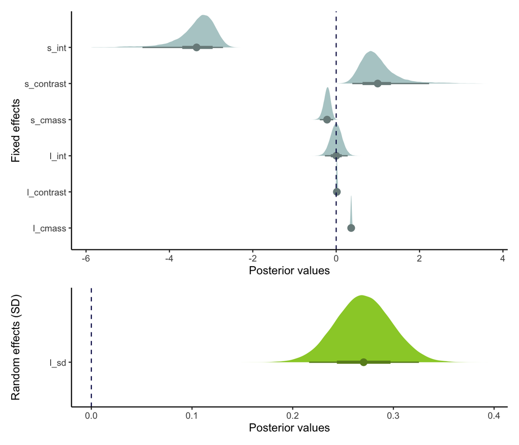

```r
# getting plots
plots_mod1 <- list(
  visualize_fixed_effects(mod1),
  visualize_random_effects(mod1)
)

plots_mod1[[1]] / plots_mod1[[2]] + plot_layout(heights = c(2, 1))
```

**Posterior distributions of different types of parameters**; the vertical dashed line indicates zero, aiding the interpretation of effect direction with thick lines showing 66% credible intervals and thin whiskers 95% credible intervals (not spanning zero being interpreted as ‘statistical significant’).

## 6.3 Result summary

- Trait variability itself is structured: larger species are less variable beak length.
- Forest dwellers are more variable, pointing to environment-specific heteroscedasticity athough the difference in the location model was limited.

# 7 Co-evolution of mean and variance (Model 4)

## 7.1 Fitting the model

The `brms` syntax for Model 4 is as follows:

```r
# creating the formula
# |p| indicates we are going to estimate correlations between these two random effects
form2 <- bf(crange_size ~1 + cmass + (1|p|gr(Phylo, cov = A)),
            sigma ~ 1 + cmass + (1|p|gr(Phylo, cov = A))
)

# setting priors
prior2 <- default_prior(form2,
                        data = dat,
                        data2 = list(A = A),
                        family = gaussian()
)

# running the model
mod2 <- brm(form2,
            data = dat,
            data2 = list(A = A),
            chains = 2,
            cores = 2,
            iter = 6000,
            warmup = 3000,
            prior = prior2,
            control = list(adapt_delta = 0.99, max_treedepth = 15)
)

# time taken to run the model
#  14265.3 seconds (Total)

# saving
saveRDS(mod2, here("Rdata", "mod2.rds"))
```

Check the results:

```r
# loading and checking
mod2 <- readRDS(here("Rdata", "mod2.rds"))

summary(mod2)
##  Family: gaussian
##   Links: mu = identity; sigma = log
## Formula: crange_size ~ 1 + cmass + (1 | p | gr(Phylo, cov = A))
##          sigma ~ 1 + cmass + (1 | p | gr(Phylo, cov = A))
##    Data: dat (Number of observations: 351)
##   Draws: 2 chains, each with iter = 6000; warmup = 3000; thin = 1;
##          total post-warmup draws = 6000
##
## Multilevel Hyperparameters:
## ~Phylo (Number of levels: 351)
##                                Estimate Est.Error l-95% CI u-95% CI Rhat
## sd(Intercept)                      3.11      0.40     2.36     3.92 1.00
## sd(sigma_Intercept)                0.78      0.15     0.51     1.10 1.00
## cor(Intercept,sigma_Intercept)    -0.94      0.05    -1.00    -0.81 1.00
##                                Bulk_ESS Tail_ESS
## sd(Intercept)                      1417     2702
## sd(sigma_Intercept)                1612     4149
## cor(Intercept,sigma_Intercept)     2677     3439
##
## Regression Coefficients:
##                 Estimate Est.Error l-95% CI u-95% CI Rhat Bulk_ESS Tail_ESS
## Intercept           0.17      1.38    -2.59     2.86 1.00     3439     3368
## sigma_Intercept     0.63      0.38    -0.12     1.36 1.00     3231     3588
## cmass              -0.25      0.23    -0.72     0.20 1.00     3378     3552
## sigma_cmass         0.18      0.08     0.03     0.33 1.00     3569     4099
##
## Draws were sampled using sampling(NUTS). For each parameter, Bulk_ESS
## and Tail_ESS are effective sample size measures, and Rhat is the potential
## scale reduction factor on split chains (at convergence, Rhat = 1).
```

## 7.2 Visualizing results

As above, using the custom functions:

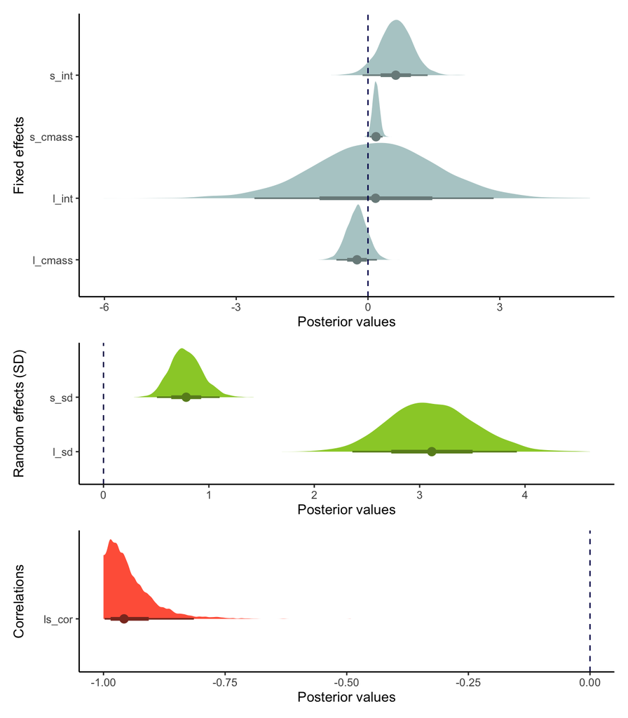

```r
# getting plots
plots_mod2 <- list(
  visualize_fixed_effects(mod2),
  visualize_random_effects(mod2),
  visualize_correlations(mod2)
)


plots_mod2[[1]] / plots_mod2[[2]] /plots_mod2[[3]] + plot_layout(heights = c(2, 1, 1))
```

**Posterior distributions of different types of parameters**; the vertical dashed line indicates zero, aiding the interpretation of effect direction with thick lines showing 66% credible intervals and thin whiskers 95% credible intervals (not spanning zero being interpreted as ‘statistical significant’).

## 7.3 Result summary

# 8 Co-evolution of two traits (Model 5)

## 8.1 Fitting the model

The `brms` syntax for Model 5 is as follows:

```r
# creating the formula
# |p| indicates we are going to estimate correlations between these 4 random effects
form3A <- bf(cbeak_width ~1 + cmass + (1|p|gr(Phylo, cov = A)),
                sigma ~ 1 + cmass + (1|p|gr(Phylo, cov = A))
)

form3B <- bf(cbeak_depth ~1 + cmass + (1|p|gr(Phylo, cov = A)),
                sigma ~ 1 + cmass + (1|p|gr(Phylo, cov = A))
)

form3 <- form3A + form3B + set_rescor(TRUE)

# setting prior
prior3 <- default_prior(form3,
                        data = dat,
                        data2 = list(A = A),
                        family = gaussian()
)

# fit model
mod3 <- brm(form3,
                  data = dat,
                  data2 = list(A = A),
                  chains = 2,
                  cores = 2,
                  iter = 15000,
                  warmup = 5000,
                  prior = prior3,
                  control = list(adapt_delta = 0.99, max_treedepth = 15)
)

summary(mod3)

# time taken to run the model
#  439397 seconds (Total)

# saving
saveRDS(mod3, here("Rdata", "mod3.rds"))
```

Check the results:

```r
# loading and checking
mod3 <- readRDS(here("Rdata", "mod3.rds"))

summary(mod3)
## Warning: There were 7 divergent transitions after warmup. Increasing
## adapt_delta above 0.99 may help. See
## http://mc-stan.org/misc/warnings.html#divergent-transitions-after-warmup
##  Family: MV(gaussian, gaussian)
##   Links: mu = identity; sigma = log
##          mu = identity; sigma = log
## Formula: cbeak_width ~ 1 + cmass + (1 | p | gr(Phylo, cov = A))
##          sigma ~ 1 + cmass + (1 | p | gr(Phylo, cov = A))
##          cbeak_depth ~ 1 + cmass + (1 | p | gr(Phylo, cov = A))
##          sigma ~ 1 + cmass + (1 | p | gr(Phylo, cov = A))
##    Data: dat (Number of observations: 354)
##   Draws: 2 chains, each with iter = 15000; warmup = 5000; thin = 1;
##          total post-warmup draws = 20000
##
## Multilevel Hyperparameters:
## ~Phylo (Number of levels: 354)
##                                                            Estimate Est.Error
## sd(cbeakwidth_Intercept)                                       0.23      0.02
## sd(sigma_cbeakwidth_Intercept)                                 0.76      0.16
## sd(cbeakdepth_Intercept)                                       0.27      0.02
## sd(sigma_cbeakdepth_Intercept)                                 0.94      0.17
## cor(cbeakwidth_Intercept,sigma_cbeakwidth_Intercept)           0.23      0.16
## cor(cbeakwidth_Intercept,cbeakdepth_Intercept)                 0.89      0.03
## cor(sigma_cbeakwidth_Intercept,cbeakdepth_Intercept)           0.28      0.16
## cor(cbeakwidth_Intercept,sigma_cbeakdepth_Intercept)           0.36      0.16
## cor(sigma_cbeakwidth_Intercept,sigma_cbeakdepth_Intercept)     0.82      0.13
## cor(cbeakdepth_Intercept,sigma_cbeakdepth_Intercept)           0.28      0.15
##                                                            l-95% CI u-95% CI
## sd(cbeakwidth_Intercept)                                       0.19     0.27
## sd(sigma_cbeakwidth_Intercept)                                 0.46     1.10
## sd(cbeakdepth_Intercept)                                       0.23     0.32
## sd(sigma_cbeakdepth_Intercept)                                 0.64     1.32
## cor(cbeakwidth_Intercept,sigma_cbeakwidth_Intercept)          -0.10     0.52
## cor(cbeakwidth_Intercept,cbeakdepth_Intercept)                 0.82     0.94
## cor(sigma_cbeakwidth_Intercept,cbeakdepth_Intercept)          -0.04     0.57
## cor(cbeakwidth_Intercept,sigma_cbeakdepth_Intercept)           0.02     0.64
## cor(sigma_cbeakwidth_Intercept,sigma_cbeakdepth_Intercept)     0.48     0.98
## cor(cbeakdepth_Intercept,sigma_cbeakdepth_Intercept)          -0.03     0.56
##                                                            Rhat Bulk_ESS
## sd(cbeakwidth_Intercept)                                   1.00     3184
## sd(sigma_cbeakwidth_Intercept)                             1.00     3910
## sd(cbeakdepth_Intercept)                                   1.00     2349
## sd(sigma_cbeakdepth_Intercept)                             1.00     2727
## cor(cbeakwidth_Intercept,sigma_cbeakwidth_Intercept)       1.00     6929
## cor(cbeakwidth_Intercept,cbeakdepth_Intercept)             1.00     3649
## cor(sigma_cbeakwidth_Intercept,cbeakdepth_Intercept)       1.00     3773
## cor(cbeakwidth_Intercept,sigma_cbeakdepth_Intercept)       1.00     5411
## cor(sigma_cbeakwidth_Intercept,sigma_cbeakdepth_Intercept) 1.00     2684
## cor(cbeakdepth_Intercept,sigma_cbeakdepth_Intercept)       1.00     5414
##                                                            Tail_ESS
## sd(cbeakwidth_Intercept)                                       7271
## sd(sigma_cbeakwidth_Intercept)                                 7196
## sd(cbeakdepth_Intercept)                                       4902
## sd(sigma_cbeakdepth_Intercept)                                 4447
## cor(cbeakwidth_Intercept,sigma_cbeakwidth_Intercept)          11541
## cor(cbeakwidth_Intercept,cbeakdepth_Intercept)                 8642
## cor(sigma_cbeakwidth_Intercept,cbeakdepth_Intercept)           7289
## cor(cbeakwidth_Intercept,sigma_cbeakdepth_Intercept)          10329
## cor(sigma_cbeakwidth_Intercept,sigma_cbeakdepth_Intercept)     3927
## cor(cbeakdepth_Intercept,sigma_cbeakdepth_Intercept)           9976
##
## Regression Coefficients:
##                            Estimate Est.Error l-95% CI u-95% CI Rhat Bulk_ESS
## cbeakwidth_Intercept          -0.05      0.13    -0.30     0.21 1.00     6878
## sigma_cbeakwidth_Intercept    -1.99      0.46    -2.90    -1.06 1.00     7701
## cbeakdepth_Intercept          -0.05      0.15    -0.34     0.24 1.00     7549
## sigma_cbeakdepth_Intercept    -1.85      0.53    -2.88    -0.80 1.00     9697
## cbeakwidth_cmass               0.32      0.01     0.29     0.34 1.00     8547
## sigma_cbeakwidth_cmass        -0.10      0.09    -0.26     0.08 1.00     6114
## cbeakdepth_cmass               0.36      0.02     0.33     0.39 1.00     7883
## sigma_cbeakdepth_cmass        -0.14      0.10    -0.36     0.06 1.00     3795
##                            Tail_ESS
## cbeakwidth_Intercept           9798
## sigma_cbeakwidth_Intercept    10102
## cbeakdepth_Intercept          11079
## sigma_cbeakdepth_Intercept    11162
## cbeakwidth_cmass              12524
## sigma_cbeakwidth_cmass        10313
## cbeakdepth_cmass              13214
## sigma_cbeakdepth_cmass         4953
##
## Residual Correlations:
##                               Estimate Est.Error l-95% CI u-95% CI Rhat
## rescor(cbeakwidth,cbeakdepth)     0.74      0.05     0.65     0.82 1.00
##                               Bulk_ESS Tail_ESS
## rescor(cbeakwidth,cbeakdepth)     6469    11074
##
## Draws were sampled using sampling(NUTS). For each parameter, Bulk_ESS
## and Tail_ESS are effective sample size measures, and Rhat is the potential
## scale reduction factor on split chains (at convergence, Rhat = 1).
```

## 8.2 Visualizing results

Again, using the custom functions:

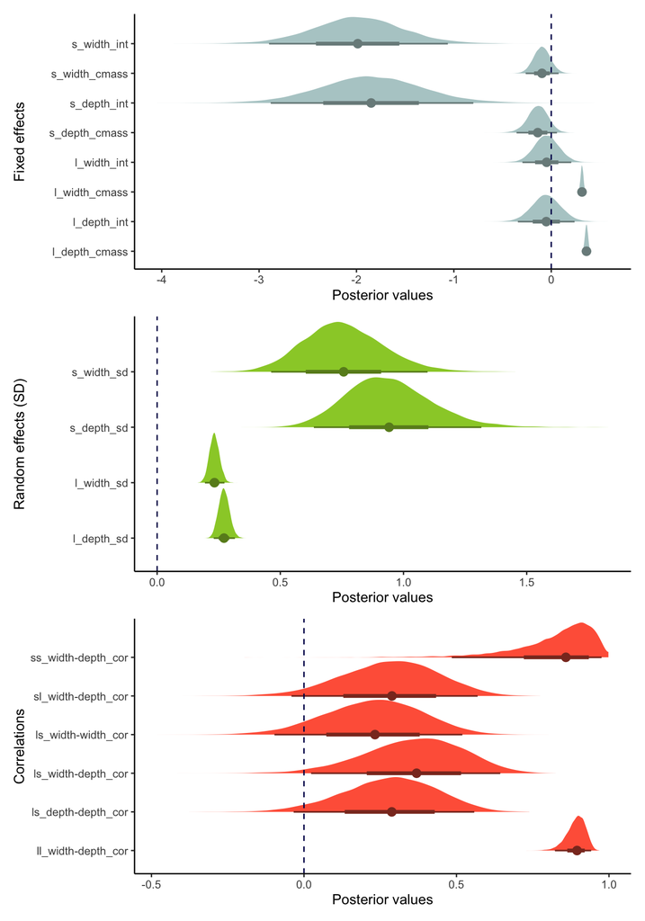

```r
# getting plots
plots_mod3 <- list(
  visualize_fixed_effects(mod3),
  visualize_random_effects(mod3),
  visualize_correlations(mod3)
)


plots_mod3[[1]] / plots_mod3[[2]] /plots_mod3[[3]]
```

**Posterior distributions of different types of parameters**; the vertical dashed line indicates zero, aiding the interpretation of effect direction with thick lines showing 66% credible intervals and thin whiskers 95% credible intervals (not spanning zero being interpreted as ‘statistical significant’).

## 8.3 Result summary

# 9 Bonus 1: implementing the Figure 2 cells in brms

This table links each conceptual cell in Figure 2 (the main text) to the corresponding distributional brms formulae and the parameters to report. Use the same group-level ID (e.g., `a`) in random effects you want correlated across parts/traits.

**Implementing the Figure 2 cells in `brms` (pseudo-code)**

Figure 2 cell / biological question

Minimal distributional formulae

Within-trait mean–variance (ρ[a(ls)])

Do lineages with larger means show greater or lower dispersion in the *same* trait?

```
bf(
  y ~ 1 + X + (1 | a | gr(species, cov = A)),
  sigma ~ 1 + X + (1 | a | gr(species, cov = A))
)
family = gaussian()
```

```
bf(
  y ~ 1 + X + (1 | a | gr(species, cov = A)),
  sigma ~ 1 + X + (1 | a | gr(species, cov = A))
)
family = gaussian()
```

Across-trait mean–mean (ρ[a(l1 l2)])

Do two traits coevolve in their means (integration vs. trade-off)?

```
bf1 <- bf(
  y1 ~ 1 + X1 + (1 | a | gr(species, cov = A)),
  sigma ~ 1 + X1 + (1 | a | gr(species, cov = A))
)
bf2 <- bf(
  y2 ~ 1 + X2 + (1 | a | gr(species, cov = A)),
  sigma ~ 1 + X2 + (1 | a | gr(species, cov = A))
)
brm(bf1 + bf2, data2 = list(A = A), family = gaussian(), ...)
```

```
bf1 <- bf(
  y1 ~ 1 + X1 + (1 | a | gr(species, cov = A)),
  sigma ~ 1 + X1 + (1 | a | gr(species, cov = A))
)
bf2 <- bf(
  y2 ~ 1 + X2 + (1 | a | gr(species, cov = A)),
  sigma ~ 1 + X2 + (1 | a | gr(species, cov = A))
)
brm(bf1 + bf2, data2 = list(A = A), family = gaussian(), ...)
```

Across-trait variance–variance (ρ[a(s1 s2)])

Do two traits co-diverge (or contra-diverge) in dispersion?

```
# same multivariate structure as above; ensure both traits have distributional parts
bf1 <- bf(
  y1 ~ 1 + X1 + (1 | a | gr(species, cov = A)),
  sigma ~ 1 + X1 + (1 | a | gr(species, cov = A))
)
bf2 <- bf(
  y2 ~ 1 + X2 + (1 | a | gr(species, cov = A)),
  sigma ~ 1 + X2 + (1 | a | gr(species, cov = A))
)
```

```
# same multivariate structure as above; ensure both traits have distributional parts
bf1 <- bf(
  y1 ~ 1 + X1 + (1 | a | gr(species, cov = A)),
  sigma ~ 1 + X1 + (1 | a | gr(species, cov = A))
)
bf2 <- bf(
  y2 ~ 1 + X2 + (1 | a | gr(species, cov = A)),
  sigma ~ 1 + X2 + (1 | a | gr(species, cov = A))
)
```

Across-trait mean–variance (ρ[a(l1 s2)], ρ[a(l2 s1)])

Does a shift in the mean of trait 1 relax or constrain variability in trait 2 (and vice versa)?

```
# same multivariate distributional model; cross-part/trait correlations learned via shared ID `a`
brm(bf1 + bf2, data2 = list(A = A), family = gaussian(), ...)
```

```
# same multivariate distributional model; cross-part/trait correlations learned via shared ID `a`
brm(bf1 + bf2, data2 = list(A = A), family = gaussian(), ...)
```

# 10 Bonus 2: obtaining phylogenetic heritability and macro-evolvability (phylogenetic CV)

Below, we show how to calculate phylogenetic heritability and macro-evolvability from the fitted `brms` object with and without a fixed effect(s). As you will see, phylogenetic heritability is fairly straightforward to obtain but macro-evolvability is a bit more complex as it is not clear what scale to calculate it on (e.g., log-scale or original scale). In fact, the same issue should be relevant to phylogenetic heritability as well but we do not consider this here.

## 10.1 a model without fixed effects

The `brms` syntax for this phylogenetic location-scale model is as follows:

```r
# creating the formula
# |p| indicates we are going to estimate correlations between these 2 random effects
form4 <- bf(crange_size ~ 1  + (1 | p | gr(Phylo, cov = A)),
            sigma ~ 1 + (1 | p | gr(Phylo, cov = A))
)

# setting prior
prior4 <- default_prior(form4,
                        data = dat,
                        data2 = list(A = A),
                        family = gaussian()
)

# fit model
mod4 <- brm(form4,
            data = dat,
            data2 = list(A = A),
            chains = 2,
            cores = 2,
            iter = 8000,
            warmup = 1000,
            prior = prior4,
            control = list(adapt_delta = 0.99, max_treedepth = 15)
)

# time taken to run the model
#  8523.23 seconds (Total)

# saving
saveRDS(mod4, here("Rdata", "mod4.rds"))
```

Check the results:

```r
# loading and checking
mod4 <- readRDS(here("Rdata", "mod4.rds"))

summary(mod4)
##  Family: gaussian
##   Links: mu = identity; sigma = log
## Formula: crange_size ~ 1 + (1 | p | gr(Phylo, cov = A))
##          sigma ~ 1 + (1 | p | gr(Phylo, cov = A))
##    Data: dat (Number of observations: 351)
##   Draws: 2 chains, each with iter = 8000; warmup = 1000; thin = 1;
##          total post-warmup draws = 14000
##
## Multilevel Hyperparameters:
## ~Phylo (Number of levels: 351)
##                                Estimate Est.Error l-95% CI u-95% CI Rhat
## sd(Intercept)                      3.14      0.43     2.34     4.02 1.00
## sd(sigma_Intercept)                0.81      0.15     0.53     1.14 1.00
## cor(Intercept,sigma_Intercept)    -0.92      0.06    -0.99    -0.77 1.00
##                                Bulk_ESS Tail_ESS
## sd(Intercept)                      2357     4994
## sd(sigma_Intercept)                2820     4818
## cor(Intercept,sigma_Intercept)     3935     4577
##
## Regression Coefficients:
##                 Estimate Est.Error l-95% CI u-95% CI Rhat Bulk_ESS Tail_ESS
## Intercept          -0.12      1.40    -2.94     2.62 1.00     3716     6128
## sigma_Intercept     0.72      0.39    -0.07     1.50 1.00     3684     5326
##
## Draws were sampled using sampling(NUTS). For each parameter, Bulk_ESS
## and Tail_ESS are effective sample size measures, and Rhat is the potential
## scale reduction factor on split chains (at convergence, Rhat = 1).
```

### 10.1.1 Phylogenetic heritability

Using Equations 14, 15 & 17 in the paper, we can calculate the phylogenetic heritability of the trait `crange_size` (the location part):

```r
# sigma2_p (total phenotypic variance)

# posterior draws
post <- as_draws_df(mod4)

# Equation 17: first calculate sigma2_e_bar (average residual variance)
sigma2_e_bar <- exp(2*post$b_sigma_Intercept + 2*post$sd_Phylo__sigma_Intercept^2)

# Equation 15 (no fixed effects)
sigma2_p <- post$sd_Phylo__Intercept^2 +  sigma2_e_bar

# Equation 14

H2l <- post$sd_Phylo__Intercept^2 / sigma2_p

#summary(H2)
quantile(H2l, probs = c(0.025, 0.5, 0.975)) %>% pander()
```

| 2.5% | 50% | 97.5% |
| --- | --- | --- |
| 0.07655 | 0.3863 | 0.7532 |

We can see the median phylogenetic heritablity is around 39%.

Using Equations 18-21 in the paper, we can calculate the phylogenetic heritability of the trait `crange_size` (the scale part):

```r
# Equation 21 - sigma2_sigma2_e (variance of the residual variance)
sigma2_sigma2_e <- (exp(4*post$sd_Phylo__sigma_Intercept^2) - 1) * exp(4*(post$b_sigma_Intercept + post$sd_Phylo__sigma_Intercept^2))

# Equation 19 - sigma2_a_star
sigma2_as_star <- sigma2_sigma2_e

# Equation 20 - sigma2_sigma2_p (variance of the total phenotypic variance)
sigma2_sigma2_p = sigma2_p ^ 2 + 3 * sigma2_sigma2_e

# Equation 18
H2s <- sigma2_as_star / sigma2_sigma2_p

#summary(H2)
quantile(H2s, probs = c(0.025, 0.5, 0.975)) %>% pander()
```

| 2.5% | 50% | 97.5% |
| --- | --- | --- |
| 0.1537 | 0.3081 | 0.3323 |

Here we found a median phylogenetic heritability of around 31%.

### 10.1.2 Macro-evolvability

Using Equations 6 in the paper, we can calculate the macro-evolvability (CV_Al) of the trait `crange_size` (log-transformed trait; the location part), but the difficulty is that we need to calculate the phylogenetic variance on the original scale. We can do this by using the delta method. The details of this calculation are provided in this earlier work (see the supplementary material):

> O’Dea RE, Noble DW, Nakagawa S. Unifying individual differences in personality, predictability and plasticity: a practical guide. Methods in Ecology and Evolution. 2022 Feb;13(2):278-93.

```r
# exp(b0) is the median of the trait
ln_b0 <- post$b_Intercept  + mean(log(dat$Range.Size), na.rm = T)
sigma2_al <- post$sd_Phylo__Intercept^2

mean_b0 <- exp(ln_b0 +  0.5 * (sigma2_al +  sigma2_e_bar) )

# conversion formula from log-scale to original scale
sd_al <- sqrt( (exp(sigma2_al) - 1) * exp(2*ln_b0 + sigma2_al) )

CV_Al <- sd_al / mean_b0

quantile(CV_Al, probs = c(0.025, 0.5, 0.975)) %>% pander()
```

| 2.5% | 50% | 97.5% |
| --- | --- | --- |
| 3.659e-24 | 0.06627 | 58.41 |

We can see the median macro-evolvability is around 0.07

```r
# alternatively, we can get CV on ln-scale
CV_Al2 <- sigma2_al / ln_b0

quantile(CV_Al2, probs = c(0.025, 0.5, 0.975)) %>% pander()
```

| 2.5% | 50% | 97.5% |
| --- | --- | --- |
| 0.4634 | 0.8535 | 1.549 |

We now estimate the macro-evolvability of the trait `crange_size` (the scale part) using Equation 24 (we assume that this CV_As is the same as the value for the original scale):

```r
CV_As <- sqrt(exp(4*post$sd_Phylo__sigma_Intercept^2) - 1)

quantile(CV_As, probs = c(0.025, 0.5, 0.975)) %>% pander()
```

| 2.5% | 50% | 97.5% |
| --- | --- | --- |
| 1.46 | 3.423 | 13.26 |

We get the median macro-evolvability of around 3.4. This is macro-evolvability of variance but we can get macro-evolvability of the standard deviation using Equation 25.

```r
# Alternatively, we can get CV_As on the SD scale

CV_As2 <- sqrt(exp(post$sd_Phylo__sigma_Intercept^2) - 1)
quantile(CV_As2, probs = c(0.025, 0.5, 0.975)) %>% pander()
```

| 2.5% | 50% | 97.5% |
| --- | --- | --- |
| 0.5746 | 0.9425 | 1.627 |

We get the median macro-evolvability of around 0.94, which is not that different from the macro-evolvability of the mean estimated on the log scale.

Also, we can use Equation 23:

```r
CV_As2 <- sqrt(sigma2_as_star) / sigma2_e_bar

quantile(CV_As2, probs = c(0.025, 0.5, 0.975), na.rm = T) %>% pander()
```

| 2.5% | 50% | 97.5% |
| --- | --- | --- |
| 1.46 | 3.423 | 13.26 |

This estimation, as expected, matches with that from Equation 24.

We also try to get the macro-evolvability for the scale part on the original scale

```r
# original scale conversion does not seem to make sense so commented out
sigma2_as_star_orig <- sqrt( (exp(sigma2_as_star) - 1) * exp(2*ln_b0 + sigma2_as_star) )
sigma2_e_bar_orig <- sqrt( (exp(sigma2_e_bar) - 1) * exp(2*ln_b0 + sigma2_e_bar) )

CV_As2_orig <- sqrt(sigma2_as_star_orig) / sigma2_e_bar_orig

quantile(CV_As2_orig, probs = c(0.025, 0.5, 0.975), na.rm = T) %>% pander()
```

| 2.5% | 50% | 97.5% |
| --- | --- | --- |
| 11483244 | Inf | Inf |

We get the median macro-evolvability of a `Inf` value so this does not seem to work.

## 10.2 a model with fixed effects

Here we use `mod2` as an example to see the phylogenetic heritability and macro-evolvability of the trait `crange_size` after controlling for body mass `cmass`.

### 10.2.1 Phylogenetic heritability

Using Equations 14-17 in the paper, we can calculate the phylogenetic heritability of the trait `crange_size` (the location part) after controlling for body mass `cmass`:

```r
# sigma2_p (total phenotypic variance)
# posterior draws
post <- as_draws_df(mod2)

# Equation 17: first calculate sigma2_e_bar (average residual variance)
sigma2_e_bar <- exp(2*post$b_sigma_Intercept + 2*post$sd_Phylo__sigma_Intercept^2)


# Equation 16 - sigma2_f (variance of the fixed effects)
sigma2_fl <- sapply(post$b_cmass, function(b) var(b*dat$cmass))

# Equation 15 (no fixed effects)
sigma2_p <- post$sd_Phylo__Intercept^2 + sigma2_fl  + sigma2_e_bar

# Equation 14
H2l <- post$sd_Phylo__Intercept^2 / sigma2_p

#summary(H2)
quantile(H2l, probs = c(0.025, 0.5, 0.975)) %>% pander()
```

| 2.5% | 50% | 97.5% |
| --- | --- | --- |
| 0.1075 | 0.4399 | 0.763 |

We can see the median phylogenetic heritablity is around 44%.

Using Equations 18-21 in the paper, we can calculate the phylogenetic heritability of the trait `crange_size` (the scale part):

```r
# Equation 22 - sigma2_fs
sigma2_fs <- sapply(post$b_sigma_cmass, function(b) var(b*dat$cmass))

# Equation 21 - sigma2_sigma2_e (variance of the residual variance)
sigma2_sigma2_e <- (exp(4*(post$sd_Phylo__sigma_Intercept^2 + sigma2_fs)) - 1) * exp(4*(post$b_sigma_Intercept + post$sd_Phylo__sigma_Intercept^2 + sigma2_fs))

# Equation 19 - sigma2_a_star
sigma2_as_star <- sigma2_sigma2_e * (post$sd_Phylo__sigma_Intercept^2 /(post$sd_Phylo__sigma_Intercept^2 + sigma2_fs))

# Equation 20 - sigma2_sigma2_p (variance of the total phenotypic variance)
sigma2_sigma2_p = sigma2_p ^ 2 + 3 * sigma2_sigma2_e

# Equation 18
H2s <- sigma2_as_star / sigma2_sigma2_p

#summary(H2)
quantile(H2s, probs = c(0.025, 0.5, 0.975)) %>% pander()
```

| 2.5% | 50% | 97.5% |
| --- | --- | --- |
| 0.1391 | 0.2877 | 0.326 |

Here we found a median phylogenetic heritability of around 29%.

### 10.2.2 Macro-evolvability

Using Equations 6 in the paper, we can calculate the macro-evolvability (CV_Al) of the trait `crange_size` (log-transformed trait; the location part), but we first need to back-transform as we did above.

```r
# exp(b0) is the median of the trait
ln_b0 <- post$b_Intercept  + mean(log(dat$Range.Size), na.rm = T)
sigma2_al <- post$sd_Phylo__Intercept^2

mean_b0 <- exp(ln_b0 +  0.5 * (sigma2_al +  sigma2_e_bar) )

# (exp(sigma_ln^2) - 1) * exp(2 * mu_ln + sigma_ln^2)
sd_al <- sqrt( (exp(sigma2_al) - 1) * exp(2*ln_b0 + sigma2_al) )

CV_Al <- sd_al / mean_b0


quantile(CV_Al, probs = c(0.025, 0.5, 0.975)) %>% pander()
```

| 2.5% | 50% | 97.5% |
| --- | --- | --- |
| 2.556e-16 | 0.3042 | 66.77 |

We can see the median macro-evolvability is around 0.30.

```r
# alternatively, we can get CV on ln-scale
CV_Al2 <- sigma2_al / ln_b0
quantile(CV_Al2, probs = c(0.025, 0.5, 0.975)) %>% pander()
```

| 2.5% | 50% | 97.5% |
| --- | --- | --- |
| 0.4576 | 0.8214 | 1.449 |

If we get the CV on the log-scale, we can see the median macro-evolvability is around 0.82, which is higher than what we got on the original scale (like above).

We now estimate the macro-evolvability of the trait `crange_size` (the scale part) using Equation 24 (we assume that this CV_As is the same as the value for the original scale):

```r
# Using Equation 24
CV_As <- sqrt(exp(4*post$sd_Phylo__sigma_Intercept^2) - 1)

quantile(CV_As, probs = c(0.025, 0.5, 0.975)) %>% pander()
```

| 2.5% | 50% | 97.5% |
| --- | --- | --- |
| 1.34 | 3.177 | 11.31 |

We get the median macro-evolvability of around 3.2. As above, this is macro-evolvability of variance but we can get macro-evolvability of the standard deviation using Equation 25.

```r
# Alternatively, we can get CV_As on the SD scale
CV_As2 <- sqrt(exp(post$sd_Phylo__sigma_Intercept^2) - 1)

quantile(CV_As2, probs = c(0.025, 0.5, 0.975)) %>% pander()
```

| 2.5% | 50% | 97.5% |
| --- | --- | --- |
| 0.5414 | 0.9083 | 1.539 |

We get the median macro-evolvability of around 0.91, which is not that different from the macro-evolvability of the mean estimated on the log scale.

Additionally, we can use Equation 23:

```r
CV_As <- sqrt(sigma2_as_star) / sigma2_e_bar

quantile(CV_As, probs = c(0.025, 0.5, 0.975), na.rm = T) %>% pander()
```

| 2.5% | 50% | 97.5% |
| --- | --- | --- |
| 1.461 | 3.628 | 14.12 |

# 11 Figure code

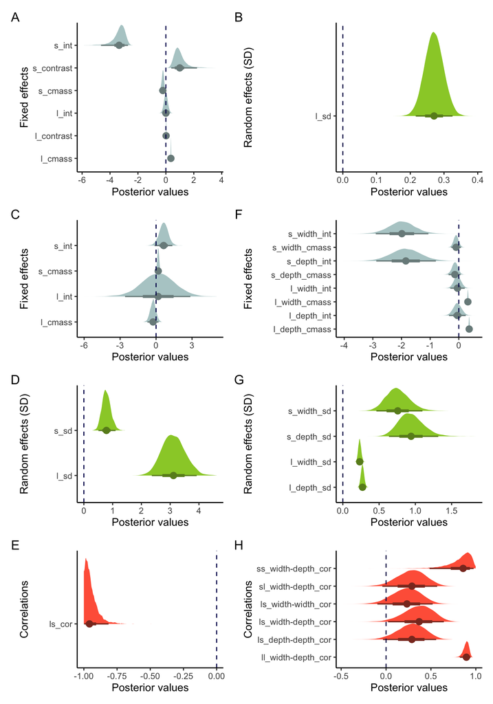

```r
# putting all plots together
(plots_mod1[[1]] + plots_mod1[[2]]) +
(plots_mod2[[1]] / plots_mod2[[2]] /plots_mod2[[3]] ) +
(plots_mod3[[1]] / plots_mod3[[2]] /plots_mod3[[3]]) + plot_layout(heights = c(1, 3), widths = c(1, 1)) +
  # put A, B, C
  plot_annotation(tag_levels = 'A')
```

# 12 Software and package versions

**R version 4.5.0 (2025-04-11)**

**Platform:** aarch64-apple-darwin20

**locale:** en_US.UTF-8||en_US.UTF-8||en_US.UTF-8||C||en_US.UTF-8||en_US.UTF-8

**attached base packages:** *stats*, *graphics*, *grDevices*, *utils*, *datasets*, *methods* and *base*

**other attached packages:** *gt(v.1.0.0)*, *pander(v.0.6.6)*, *patchwork(v.1.3.1)*, *ape(v.5.8-1)*, *here(v.1.0.1)*, *tidybayes(v.3.0.7)*, *bayesplot(v.1.13.0)*, *brms(v.2.22.0)*, *Rcpp(v.1.1.0)*, *lubridate(v.1.9.4)*, *forcats(v.1.0.0)*, *stringr(v.1.5.1)*, *dplyr(v.1.1.4)*, *purrr(v.1.1.0)*, *readr(v.2.1.5)*, *tidyr(v.1.3.1)*, *tibble(v.3.3.0)*, *ggplot2(v.3.5.2)*, *tidyverse(v.2.0.0)* and *pacman(v.0.5.1)*

**loaded via a namespace (and not attached):** *tidyselect(v.1.2.1)*, *svUnit(v.1.0.6)*, *farver(v.2.1.2)*, *loo(v.2.8.0)*, *fastmap(v.1.2.0)*, *TH.data(v.1.1-3)*, *tensorA(v.0.36.2.1)*, *digest(v.0.6.37)*, *estimability(v.1.5.1)*, *timechange(v.0.3.0)*, *lifecycle(v.1.0.4)*, *StanHeaders(v.2.32.10)*, *survival(v.3.8-3)*, *magrittr(v.2.0.3)*, *posterior(v.1.6.1)*, *compiler(v.4.5.0)*, *sass(v.0.4.10)*, *rlang(v.1.1.6)*, *tools(v.4.5.0)*, *yaml(v.2.3.10)*, *knitr(v.1.50)*, *labeling(v.0.4.3)*, *bridgesampling(v.1.1-2)*, *htmlwidgets(v.1.6.4)*, *curl(v.6.4.0)*, *pkgbuild(v.1.4.8)*, *xml2(v.1.3.8)*, *plyr(v.1.8.9)*, *RColorBrewer(v.1.1-3)*, *multcomp(v.1.4-28)*, *abind(v.1.4-8)*, *withr(v.3.0.2)*, *grid(v.4.5.0)*, *stats4(v.4.5.0)*, *colorspace(v.2.1-1)*, *xtable(v.1.8-4)*, *inline(v.0.3.21)*, *emmeans(v.1.11.2)*, *scales(v.1.4.0)*, *MASS(v.7.3-65)*, *cli(v.3.6.5)*, *mvtnorm(v.1.3-3)*, *rmarkdown(v.2.29)*, *generics(v.0.1.4)*, *RcppParallel(v.5.1.10)*, *rstudioapi(v.0.17.1)*, *reshape2(v.1.4.4)*, *tzdb(v.0.5.0)*, *commonmark(v.2.0.0)*, *rstan(v.2.32.7)*, *splines(v.4.5.0)*, *parallel(v.4.5.0)*, *base64enc(v.0.1-3)*, *matrixStats(v.1.5.0)*, *vctrs(v.0.6.5)*, *V8(v.6.0.5)*, *Matrix(v.1.7-3)*, *sandwich(v.3.1-1)*, *jsonlite(v.2.0.0)*, *litedown(v.0.7)*, *hms(v.1.1.3)*, *arrayhelpers(v.1.1-0)*, *ggdist(v.3.3.3)*, *glue(v.1.8.0)*, *codetools(v.0.2-20)*, *distributional(v.0.5.0)*, *stringi(v.1.8.7)*, *gtable(v.0.3.6)*, *QuickJSR(v.1.8.0)*, *pillar(v.1.11.0)*, *htmltools(v.0.5.8.1)*, *Brobdingnag(v.1.2-9)*, *R6(v.2.6.1)*, *rprojroot(v.2.1.0)*, *evaluate(v.1.0.4)*, *lattice(v.0.22-7)*, *markdown(v.2.0)*, *backports(v.1.5.0)*, *rstantools(v.2.4.0)*, *gridExtra(v.2.3)*, *coda(v.0.19-4.1)*, *nlme(v.3.1-168)*, *checkmate(v.2.3.2)*, *xfun(v.0.52)*, *zoo(v.1.8-14)* and *pkgconfig(v.2.0.3)*